# Basic R for Graphics"

### HW4 Test Score Classification

### 11.22.2015

### Packages: ggplot2, data.tables

Perfect Colinearity: see video [https://www.youtube.com/watch?v=DDRQYKVFoP0]

Multilinearity: see video [https://www.youtube.com/watch?v=O4jDva9B3fw]

NYC Dept of Ed. standardized test score data Grades 3-8:  
see: [http://schools.nyc.gov/Accountability/data/TestResults/ELAandMathTestResults]

# Setup and Load data

1. Load the New York City English Language Arts test scores dataset by District, Grade and Year. ggplot2 package. Identify variables as numeric or categorical (factors).

```r
## Load Data Frame from website
require(data.table)
```

```r
require(ggplot2)
#ELAByDistrictUrl <- "/Users/scottkarr/Downloads/District ELA Results 2013-2015.csv"
ELAByDistrictUrl <- "https://raw.githubusercontent.com/scottkarr/hw4/master/District%20ELA%20Results%202013-2015.csv"
df_ELAByDistrict <- read.table(file = ELAByDistrictUrl, header = TRUE, sep = ",")
dt_ELAByDistrict <- data.table(df_ELAByDistrict)
```

## Generate Descriptive Statistics

2. Generate summary level descriptive statistics:

```r
head(df_ELAByDistrict)
```

```
##   District Grade Year     Category Number.Tested Mean.Scale.Score Lvl1Cnt
## 1        1     3 2013 All Students           877              303     310
## 2        1     3 2014 All Students           845              299     333
## 3        1     3 2015 All Students           750              303     264
## 4        1     4 2013 All Students           830              304     238
## 5        1     4 2014 All Students           824              307     222
## 6        1     4 2015 All Students           771              303     226
##   Lvl1Pct Lvl2Cnt Lvl2Pct Lvl3Cnt Lvl3Pct Lvl4Cnt Lvl4Pct PassCnt PassPct
## 1    35.3     266    30.3     224    25.5      77     8.8     301    34.3
## 2    39.4     213    25.2     232    27.5      67     7.9     299    35.4
## 3    35.2     205    27.3     191    25.5      90    12.0     281    37.5
## 4    28.7     306    36.9     169    20.4     117    14.1     286    34.5
## 5    26.9     274    33.3     174    21.1     154    18.7     328    39.8
## 6    29.3     265    34.4     143    18.5     137    17.8     280    36.3
```

```r
str(df_ELAByDistrict)
```

```
## 'data.frame':    672 obs. of  16 variables:
##  $ District        : int  1 1 1 1 1 1 1 1 1 1 ...
##  $ Grade           : Factor w/ 7 levels "3","4","5","6",..: 1 1 1 2 2 2 3 3 3 4 ...
##  $ Year            : int  2013 2014 2015 2013 2014 2015 2013 2014 2015 2013 ...
##  $ Category        : Factor w/ 1 level "All Students": 1 1 1 1 1 1 1 1 1 1 ...
##  $ Number.Tested   : int  877 845 750 830 824 771 773 757 790 875 ...
##  $ Mean.Scale.Score: int  303 299 303 304 307 303 302 300 304 303 ...
##  $ Lvl1Cnt         : int  310 333 264 238 222 226 267 264 251 248 ...
##  $ Lvl1Pct         : num  35.3 39.4 35.2 28.7 26.9 29.3 34.5 34.9 31.8 28.3 ...
##  $ Lvl2Cnt         : int  266 213 205 306 274 265 270 237 228 342 ...
##  $ Lvl2Pct         : num  30.3 25.2 27.3 36.9 33.3 34.4 34.9 31.3 28.9 39.1 ...
##  $ Lvl3Cnt         : int  224 232 191 169 174 143 144 144 160 90 ...
##  $ Lvl3Pct         : num  25.5 27.5 25.5 20.4 21.1 18.5 18.6 19 20.3 10.3 ...
##  $ Lvl4Cnt         : int  77 67 90 117 154 137 92 112 151 195 ...
##  $ Lvl4Pct         : num  8.8 7.9 12 14.1 18.7 17.8 11.9 14.8 19.1 22.3 ...
##  $ PassCnt         : int  301 299 281 286 328 280 236 256 311 285 ...
##  $ PassPct         : num  34.3 35.4 37.5 34.5 39.8 36.3 30.5 33.8 39.4 32.6 ...
```

## Prepare Dataset for Graphics

3. Index by District

```r
## Create column class as key column for indexing
setkey(dt_ELAByDistrict, District)
```

4. Filter on “2015” and limit dataset to percentages by level and District, Grade, Year.

```r
ans2 <- dt_ELAByDistrict[ Year == 2015 , .(District, Grade, Year, Lvl1Pct, Lvl2Pct, Lvl3Pct, Lvl4Pct, PassPct)]
```

5. Histogram showing Passing percentages for 2015 by District. Note 4 distinct groupings which are related to levels

```
## stat_bin: binwidth defaulted to range/30. Use 'binwidth = x' to adjust this.
```

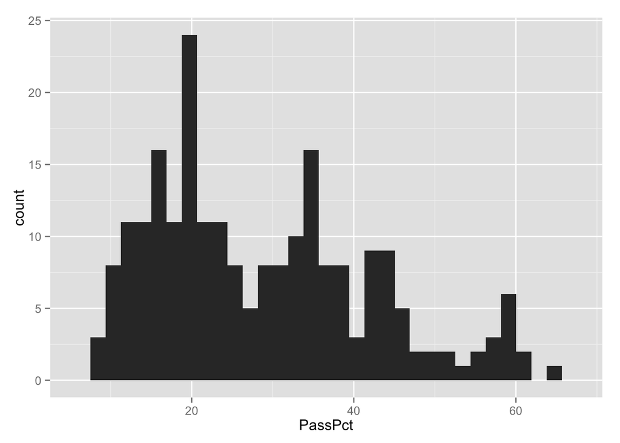

```r
ggplot(data = ans2) + geom_histogram(aes(x = PassPct))
```

6. Scatterplot superimposing scatterplot and box diagram, grouped by Grade. Data compares 2015 ELA level1 percentages to passing percentages(level3 & level4). Note the negative correlation since passing and level 1 scores are mutually exclusive, one would expect an inverse relationship between passing and level1 1 percentages.

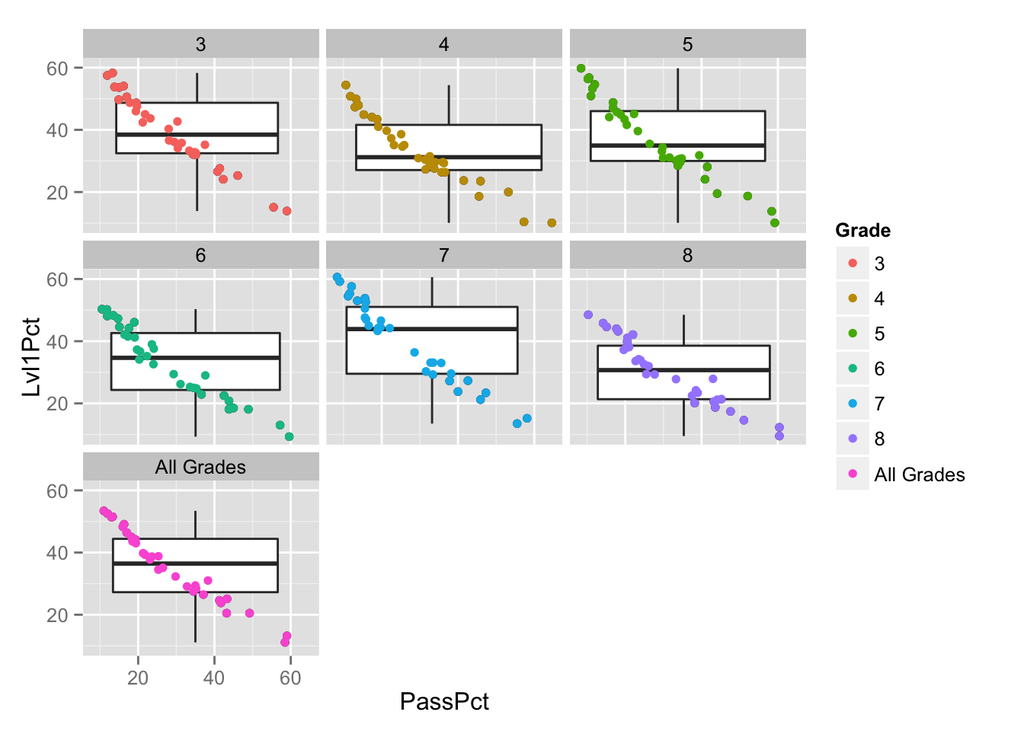

```r
g <- ggplot(ans2, aes(x = PassPct, y = Lvl1Pct)) + geom_point() + geom_boxplot()
g <- g + geom_point(aes(color = Grade)) + facet_wrap(~Grade)
g
```

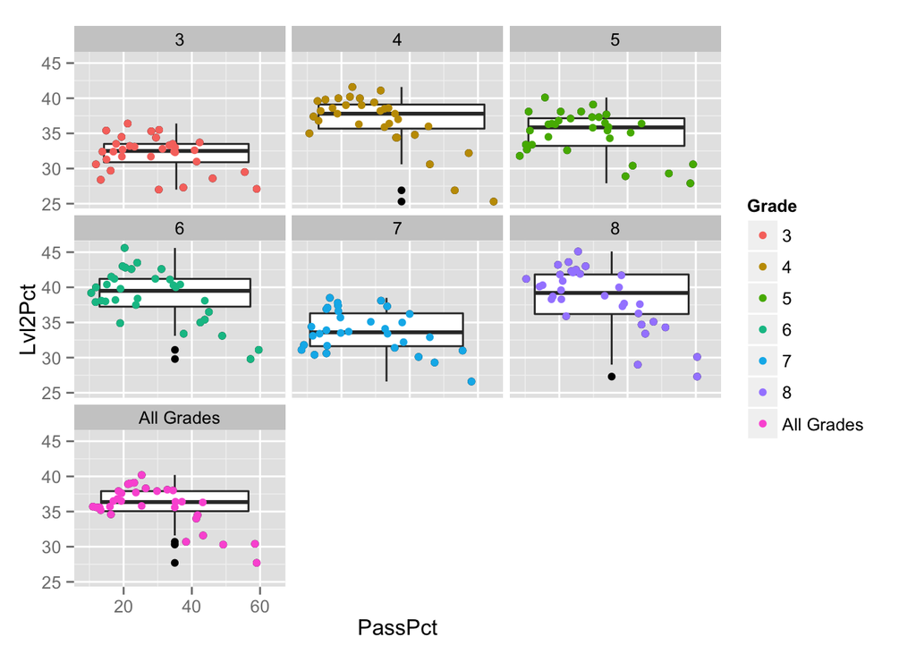

```r
g <- ggplot(ans2, aes(x = PassPct, y = Lvl2Pct)) + geom_point() + geom_boxplot()
g <- g + geom_point(aes(color = Grade)) + facet_wrap(~Grade)
g
```

8. Scatterplot superimposing scatterplot and box diagram, grouped by Grade. Data compares 2015 ELA level3 percentages to passing percentages(level3 & level4). Note the positive correlation since passing and level 3 & 4 scores are colinear. Also note that lower level2 scores show up as higher level 3 scores.

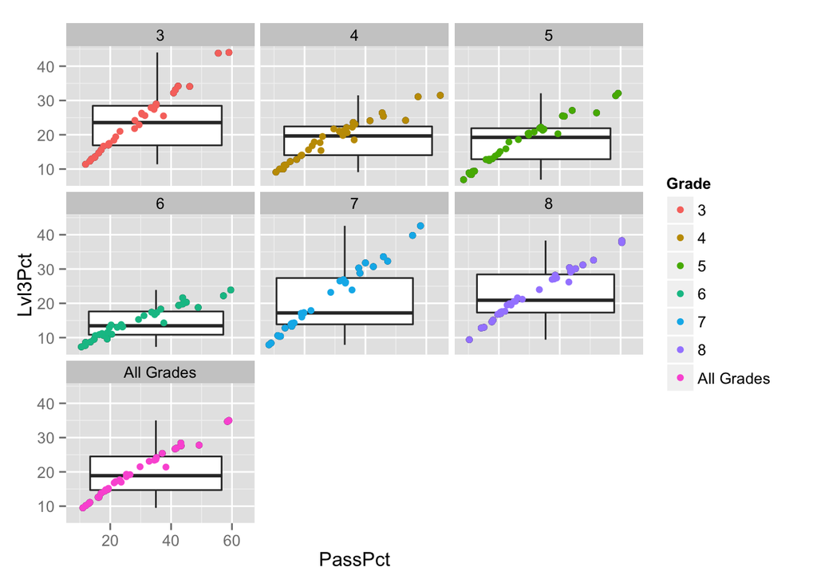

```r
g <- ggplot(ans2, aes(x = PassPct, y = Lvl3Pct)) + geom_point() + geom_boxplot()
g <- g + geom_point(aes(color = Grade)) + facet_wrap(~Grade)
g
```

9. Scatterplot superimposing scatterplot and box diagram, grouped by Grade. Data compares 2015 ELA level4 percentages to passing percentages(level3 & level4). Note the positive correlation between passing and level4 percentages.

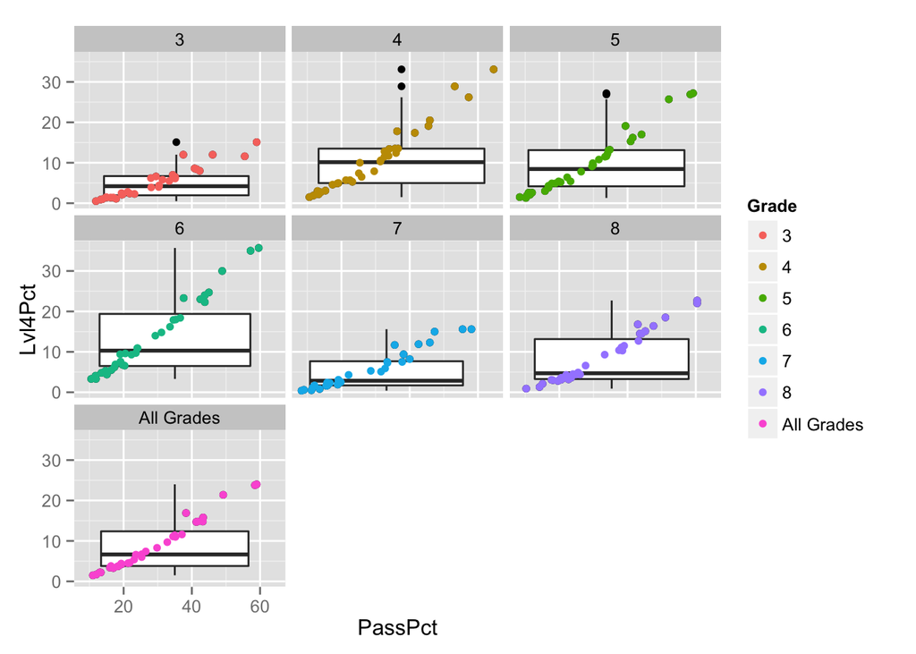

```r
g <- ggplot(ans2, aes(x = PassPct, y = Lvl4Pct)) + geom_point() + geom_boxplot()
g <- g + geom_point(aes(color = Grade)) + facet_wrap(~Grade)
g
```

10. Scatterplot superimposing scatterplot and box diagram, grouped by Grade. Data compares 2015 ELA level4 percentages to passing percentages(level3 & level4). Note the positive correlation between passing and level4 percentages.

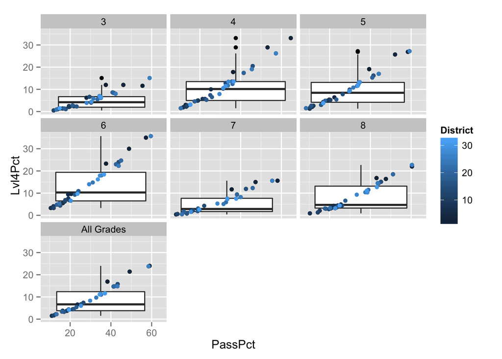

```r
g <- ggplot(ans2, aes(x = PassPct, y = Lvl4Pct)) + geom_point() + geom_boxplot()
g <- g + geom_point(aes(color = District)) + facet_wrap(~Grade)
g
```